# Empirical Bayes - Robbin’s Formula / Gamma MLE

Peter Gross

1/27/2017

## Empirical Bayes

This post is going to examine and implement the formulaic journey in Chapter 6.1 - Robbin’s Forma (Efron and Hastie 2016, pg. 75-78) to assist in following the statistical augments the authors put forward.

In the example we analyse the counts $y_x$ of claims $x$ made by 9461 automobile insurance policy holders. It starts by looking at a overall level of the number of claims made in a year for all policy holders and attempts to estimate the number of claims a single policy holder *k* will make in the next year.

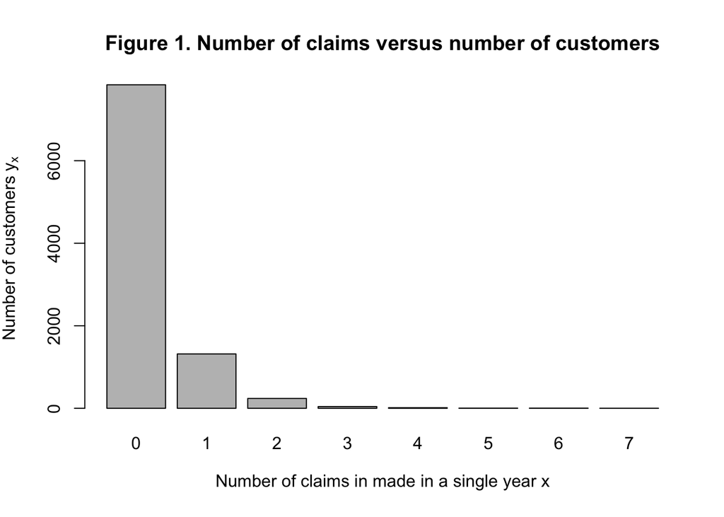

```r
x <- seq(0, 7)
y <- c(7840, 1317, 239, 42, 14, 4, 4, 1)

barplot(y, names.arg = x, main = "Figure 1. Number of claims versus number of customers",
    xlab = expression("Number of claims in made in a single year " * x), ylab = expression("Number of customers " *
        y[x]))
```

```r
kable(data.frame(x, y), caption = "Table 1. Claim counts $y_x$ by number of customers that made them $x$",
    col.names = c("$x$", "$y_x$"))
```

Table 1. Claim counts $y_x$ by number of customers that made them $x$

| $x$ | $y_x$ |
| --- | --- |
| 0 | 7840 |
| 1 | 1317 |
| 2 | 239 |
| 3 | 42 |
| 4 | 14 |
| 5 | 4 |
| 6 | 4 |
| 7 | 1 |

The first step is to assume that the number of claims made by a policy holder follows a Poisson distribution. The trick is that different policy holders will have their own rate of making claims $\theta_k$.

## Calculation

The first ascertian is that the distribution is a Poisson (“Poisson Distributions” 2017), a discrete probability distribution that expresses the probability of a given number of events occuring in a fixed interval of time and / or space.

$$Pr\{x_k = x\} = p_{\theta_k}(x) = e^{-\theta_k}\theta_k^x/x!\tag{1.1}$$

$\theta_k$ is the expected value of $x_k$. Based on the Bayes rule we calculate the expected value of (1.1) with a $g(\theta)$ prior:

$$E\{\theta|x\}=\frac{\int_0^\infty \theta p_\theta(x)g(\theta)d\theta}{\int_0^\infty p_\theta(x)g(\theta)d\theta}\tag{1.2}$$

The *marginal density* (i.e. the denominator) of $x$ is defined by:

$$f(x)=\int_0^\infty p_\theta(x)g(\theta)d\theta=\int_0^\infty[e^{-\theta}\theta^x/x!]g(\theta)d(\theta)\tag{1.3}$$

And the *Robbin’s formula* is given by (refer text):

$$E\{\theta|x\}=(x+1)f(x+1)/f(x)\tag{1.4}$$

A crude estimate of (1.3) is made as follows:

$$\hat{f}=y_x/N, \textrm{ with } N = \sum_x y_x\tag{1.5}$$

Which yields an empirical version of *Robbin’s formula*:

$$\hat{E}\{\theta|x\}=(x+1)\hat{f}(x+1)/\hat{f}(x)=(x+1)y_{x+1}/y_x\tag{1.6}$$

```r
N <- sum(y)
fhat <- y/N

Ehat <- 0

for (i in 1:length(x)-1) {
  Ehat[i] = i * y[i + 1] / y[i]
}
Ehat <- c(Ehat, NA)

kable(data.frame(x, Ehat), caption = "Expected claims using the empirical approach", digits = 3, col.names=c("$x$", "$Formula (1.5)$"))
```

Expected claims using the empirical approach

| $x$ | $Formula (1.5)$ |
| --- | --- |
| 0 | 0.168 |
| 1 | 0.363 |
| 2 | 0.527 |
| 3 | 1.333 |
| 4 | 1.429 |
| 5 | 6.000 |
| 6 | 1.750 |
| 7 | NA |

This corresponds to the results found in Table 6.1 (Efron and Hastie 2016) with the difference that the expected claims for policy holders that had previously made 6 claims is 1.75 and not 1.25.

## Parametric Approach

As indicated in the text and what can be see in the above table, the empirical *Robbin’s formula* becomes unstable at the higher numbers of *x*. To address this we attempt to fit the observed distribution by assuming the prior function to be a gamma distribution (see (“Gamma Distribution” 2017)):

$$g(\theta)=\frac{\theta^{v-1}e^{-\theta/\sigma}}{\sigma^v\Gamma(v)}\tag{1.7}$$

As indicated (Efron and Hastie 2016, pg. 89), combining the gamma prior (1.7) with the Poisson density (1.1) we get:

$$f_{v,\sigma}(x)=\frac{\int_0^{\infty}\theta^{v+x-1}e^{-\theta/\gamma}d\theta}{\sigma^v\Gamma(v)x!}\tag{1.8}$$
$$=\frac{\gamma^{v+x}\Gamma(v+x)}{\sigma^v \Gamma(v) x!}\tag{1.9}$$

where $\gamma = \sigma/(1 + \sigma)$. Through my own derivation of the above, I get to the following variation of the equation 1.9.

$$=\frac{\gamma^{(v+x)-1}\Gamma(v+x)}{\sigma^v \Gamma(v) x!}\tag{1.10}$$

To determine the parameters of (1.7) we make use of a Maximum Likelihood Estimation (“Maximum Likelihood Estimation” 2017). The log likelihood function for the accident data is given:

$$\sum_{x=0}^{x_{max}}y_x log\{f_{v,\sigma}(x)\}\tag{1.11}$$

The authors miss the step for calculating these values and that is what will be undertaken here. The solution for a gamma likelihood function is given here (“Likelihood Function” 2017). The *marginal density* (1.9) can be used to find the maximum likelihood estimation (MLE).

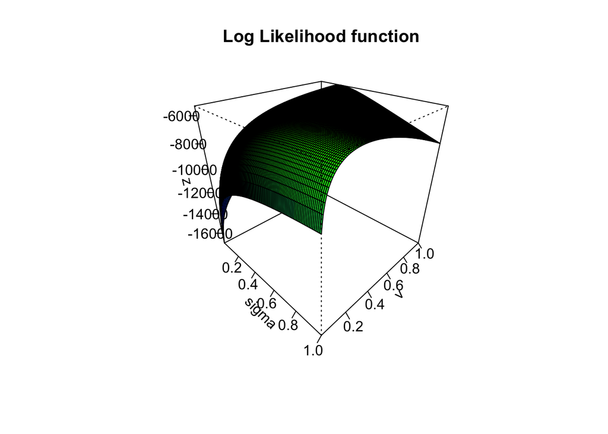

```r
x <- seq(0, 7)
y <- c(7840, 1317, 239, 42, 14, 4, 4, 1)
sigma <- seq(0.01, 1, by= 0.01)
v <- seq(0.01, 1, by= 0.01)

z <- matrix(nrow=length(sigma), ncol=length(v), dimnames = list(sigma, v))

for (k in 1:length(sigma)) { # By row
        for (j in 1:length(v)) { # By column
                val1 <- 0
                for (i in 1:length(x)) {
                        val1 <- val1 + y[i] * log ( (sigma[k]/(1+sigma[k]))^(v[j] + x[i]) * gamma(v[j] + x[i]) / ( (sigma[k]^v[j])*gamma(v[j])*factorial(x[i]) ) )
                }
                z[k, j] <- val1
        }
}

#plot(v, val2, type="l")
nrz <- nrow(z)
ncz <- ncol(z)
# Create a function interpolating colors in the range of specified colors
jet.colors <- colorRampPalette( c("blue", "green") )
# Generate the desired number of colors from this palette
nbcol <- 15
color <- jet.colors(nbcol)
# Compute the z-value at the facet centres
zfacet <- z[-1, -1] + z[-1, -ncz] + z[-nrz, -1] + z[-nrz, -ncz]
# Recode facet z-values into color indices
facetcol <- cut(zfacet, nbcol)

persp(x = sigma, y = v, z = z, col = color[facetcol], phi=30, theta=45, main = "Log Likelihood function", ticktype = "detailed")
```

```r
sigmaRslt = sigma[which(z==max(z)) %% nrow(z)]
vRslt = v[which(z==max(z)) %/% ncol(z)]

kable(data.frame(sigmaRslt, vRslt), caption = "Table 2. Gamma Parameters", col.names=c("$σ_{result}$", "$v_{result}$"))
```

Table 2. Gamma Parameters

| $σ_{result}$ | $v_{result}$ |
| --- | --- |
| 0.31 | 0.68 |

Having found the gamma distribution parameters we are able to then calculate the expected claims $\theta_k$

```r
sigma1 = sigmaRslt
v1 = vRslt
N=sum(y)

gMLE <- c()

for (i in 1:length(x)) {
gMLE <- c(gMLE, (sigma1/(1+sigma1))^(v1+x[i])*gamma(v1+x[i])/((sigma1^v1)*gamma(v1)*factorial(x[i])))
}

EhatGMLE <- c()
for (i in 1:length(x)-1) {
  EhatGMLE <- c(EhatGMLE, x[i+1] * gMLE[i+1]/gMLE[i])
}
EhatGMLE <- c(EhatGMLE, NA)

kable(data.frame(x, Ehat, EhatGMLE), digits = 3, caption="Table 3. Resultant expected claims for the following year", col.names=c("$x$", "$Formula (1.5)$", "Gamma MLE (Est)"))
```

Table 3. Resultant expected claims for the following year

| $x$ | $Formula (1.5)$ | Gamma MLE (Est) |
| --- | --- | --- |
| 0 | 0.168 | 0.161 |
| 1 | 0.363 | 0.398 |
| 2 | 0.527 | 0.634 |
| 3 | 1.333 | 0.871 |
| 4 | 1.429 | 1.107 |
| 5 | 6.000 | 1.344 |
| 6 | 1.750 | 1.581 |
| 7 | NA | NA |

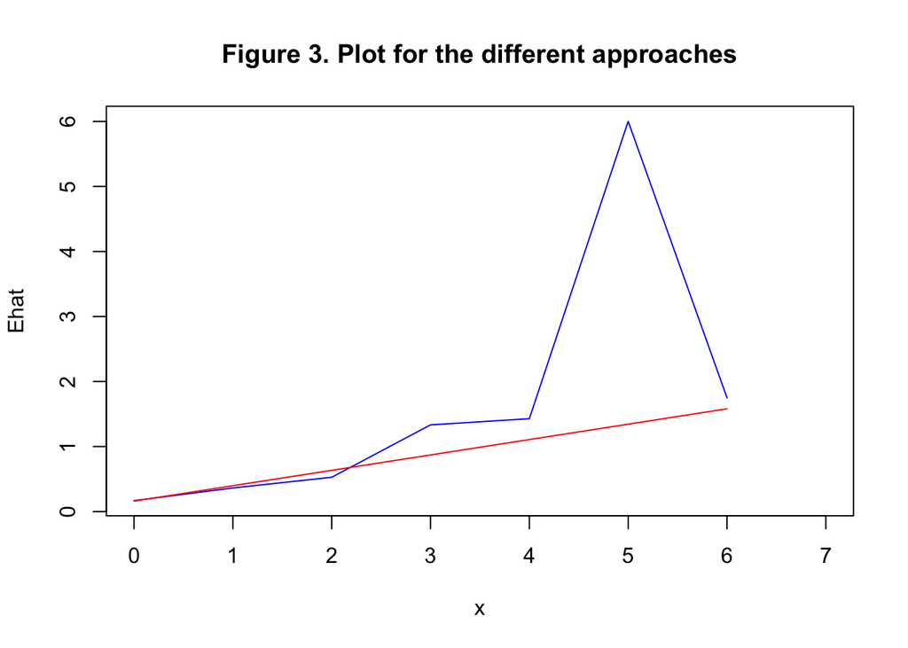

```r
plot(x, Ehat, col="blue", type="l", main="Figure 3. Plot for the different approaches")
lines(x, EhatGMLE, col="red")
```

The results of the parameter estimation are close enough to the text (Efron and Hastie 2016) Table 6.1. to have proved the point of the exercise. The follow section outlines however we’d take a calculated approach to determine the gamma function parameters.

## Further calculations to obtain the absolute maximum likelihood values

And using the chain rule gives the *score function* eq.4.14 from (Efron and Hastie 2016, pg.42) that equals zero. In this case the $\theta$ represents the parameters $v, \sigma$ in (1.10).

$$i_x(\theta) = \frac{\partial}{\partial\theta} log f_\theta(x) = \dot{f_\theta}(x)/f_\theta(x) = 0\tag{1.12}$$

It is indicated that the *Fisher information $I_\theta$* is defined as the variance of the score function from eq. 4.16 in the text (Efron and Hastie 2016, pg.42).

$$I_\theta = \int_{\chi} i_x(\theta)^2 f_\theta(x) dx \tag{1.13}$$

and the estimate of the parameter $\hat{\theta}$ from (Efron and Hastie 2016, pg.42) eq.4.18:

$$\hat{\theta} \dot{\sim} N(\theta, 1/I_\theta)\tag{1.14}$$

To calculate this we need to take the partial differntial of the log likelihood with respect to $\sigma$ and $v$:

$$\frac{\partial log \mathcal{L} (v,\sigma | \mathbf{x})} {\partial v} = log \gamma + \frac{1}{v+x} - log \sigma - \frac{\Gamma'(v)}{\Gamma(v)}\tag{1.15}$$

$$\frac{\partial log \mathcal{L} (v,\sigma | \mathbf{x})} {\partial x} = log \gamma + \frac{1}{v+x}\tag{1.16}$$
The psi-gamma function is defined as:

$$\psi(v)=\frac{\Gamma'(v)}{\Gamma(v)}\tag{1.17}$$

It is at this point that the marginal benefit of calculating the absolute maximum values of the gamma function is weighted against the effort of deriving a neat formulaic result. We stop at this point.

## References

Efron, Bradley, and Trevor Hastie. 2016. *Computer Age Statistical Inference: Algorithms, Evidence, and Data Science*. Institute of Mathematical Statistics Monographs. Cambridge.

“Gamma Distribution.” 2017. Wikipedia. Accessed January. https://en.wikipedia.org/wiki/Gamma_distribution.

“Likelihood Function.” 2017. Wikipedia. Accessed January. https://en.wikipedia.org/wiki/Likelihood_function.

“Maximum Likelihood Estimation.” 2017. Wikipedia. Accessed January. https://en.wikipedia.org/wiki/Maximum_likelihood_estimation.

“Poisson Distributions.” 2017. Wikipedia. Accessed January. https://en.wikipedia.org/wiki/Poisson_distribution.